# IMPLEMENTATION AND COMPARATIVE ANALYSIS OF MACHINE LEARNING MODELS

# INTRODUCTION

#### In this notebook, we aim to implement and compare the performance of various machine learning models on a given dataset. The models under consideration include:

- Random Forest Classifier
- K-Nearest Neighbors (KNN)
- Decision Tree Classifier
- Logistic Regression
- Artificial Neural Network (ANN)

#### Each model will be evaluated based on its accuracy, confusion matrix, and classification report. The purpose of this comparative analysis is to identify the most effective model for the dataset and understand the strengths and weaknesses of each approach. Through this comprehensive evaluation, we aim to provide insights into the performance of different machine learning algorithms, thereby aiding in the selection of the most appropriate model for predictive tasks in similar contexts.

# SETUP

```python
import time
import pandas as pd
import matplotlib.pyplot as plt
import seaborn as sns
import numpy as np
import tensorflow as tf
from sklearn.compose import ColumnTransformer
from sklearn.preprocessing import LabelEncoder
from sklearn.preprocessing import OneHotEncoder
from sklearn.preprocessing import StandardScaler
from sklearn.impute import SimpleImputer
from sklearn.pipeline import Pipeline
from sklearn.pipeline import make_pipeline
from sklearn.feature_selection import RFE
from sklearn.feature_selection import SelectKBest, f_classif
from sklearn.model_selection import train_test_split
from sklearn.ensemble import RandomForestClassifier
from sklearn.neighbors import KNeighborsClassifier
from sklearn.tree import DecisionTreeClassifier
from sklearn.linear_model import LogisticRegression
from sklearn.metrics import accuracy_score, confusion_matrix, classification_report
from tensorflow.keras.models import Sequential
from tensorflow.keras.layers import Dense, Dropout
from tensorflow.keras.layers import BatchNormalization, Dropout
from tensorflow.keras.models import load_model
```

# 1- DATA EXPLORATION AND UNDERSTANDING

### Loading and reading dataset

```python
# Load the dataset into a Pandas DataFrame
df = pd.read_csv("healthcare-dataset-stroke-data.csv")

# Display the first few rows of the DataFrame to get an initial overview
df.head()
```

|  | id | gender | age | hypertension | heart_disease | ever_married | work_type | Residence_type | avg_glucose_level | bmi | smoking_status | stroke |
| --- | --- | --- | --- | --- | --- | --- | --- | --- | --- | --- | --- | --- |
| 0 | 9046 | Male | 67.0 | 0 | 1 | Yes | Private | Urban | 228.69 | 36.6 | formerly smoked | 1 |
| 1 | 51676 | Female | 61.0 | 0 | 0 | Yes | Self-employed | Rural | 202.21 | NaN | never smoked | 1 |
| 2 | 31112 | Male | 80.0 | 0 | 1 | Yes | Private | Rural | 105.92 | 32.5 | never smoked | 1 |
| 3 | 60182 | Female | 49.0 | 0 | 0 | Yes | Private | Urban | 171.23 | 34.4 | smokes | 1 |
| 4 | 1665 | Female | 79.0 | 1 | 0 | Yes | Self-employed | Rural | 174.12 | 24.0 | never smoked | 1 |

### Dataset Information

```python
# Display concise summary information about the DataFrame, including data types and non-null values
df_info = df.info()
```

```
<class 'pandas.core.frame.DataFrame'>
RangeIndex: 5110 entries, 0 to 5109
Data columns (total 12 columns):
 #   Column             Non-Null Count  Dtype
---  ------             --------------  -----
 0   id                 5110 non-null   int64
 1   gender             5110 non-null   object
 2   age                5110 non-null   float64
 3   hypertension       5110 non-null   int64
 4   heart_disease      5110 non-null   int64
 5   ever_married       5110 non-null   object
 6   work_type          5110 non-null   object
 7   Residence_type     5110 non-null   object
 8   avg_glucose_level  5110 non-null   float64
 9   bmi                4909 non-null   float64
 10  smoking_status     5110 non-null   object
 11  stroke             5110 non-null   int64
dtypes: float64(3), int64(4), object(5)
memory usage: 479.2+ KB
```

### Descriptive statistics of the numerical columns

```python
# Generate descriptive statistics of the numerical columns in the DataFrame
df_describe = df.describe()

# Display the descriptive statistics
df_describe
```

|  | id | age | hypertension | heart_disease | avg_glucose_level | bmi | stroke |
| --- | --- | --- | --- | --- | --- | --- | --- |
| count | 5110.000000 | 5110.000000 | 5110.000000 | 5110.000000 | 5110.000000 | 4909.000000 | 5110.000000 |
| mean | 36517.829354 | 43.226614 | 0.097456 | 0.054012 | 106.147677 | 28.893237 | 0.048728 |
| std | 21161.721625 | 22.612647 | 0.296607 | 0.226063 | 45.283560 | 7.854067 | 0.215320 |
| min | 67.000000 | 0.080000 | 0.000000 | 0.000000 | 55.120000 | 10.300000 | 0.000000 |
| 25% | 17741.250000 | 25.000000 | 0.000000 | 0.000000 | 77.245000 | 23.500000 | 0.000000 |
| 50% | 36932.000000 | 45.000000 | 0.000000 | 0.000000 | 91.885000 | 28.100000 | 0.000000 |
| 75% | 54682.000000 | 61.000000 | 0.000000 | 0.000000 | 114.090000 | 33.100000 | 0.000000 |
| max | 72940.000000 | 82.000000 | 1.000000 | 1.000000 | 271.740000 | 97.600000 | 1.000000 |

### Shape of the DataFrame

```python
# Get the dimensions of the DataFrame (number of rows and columns)
df_shape = df.shape

# Display the shape of the DataFrame
print("DataFrame Shape:", df_shape)
```

```
DataFrame Shape: (5110, 12)
```

### Check for missing values

```python
# Check for missing values in each column and sum them up
missing_values = df.isna().sum()

# Display the count of missing values for each column
print("Missing Values per Column:")
print(missing_values)
```

```
Missing Values per Column:
id                     0
gender                 0
age                    0
hypertension           0
heart_disease          0
ever_married           0
work_type              0
Residence_type         0
avg_glucose_level      0
bmi                  201
smoking_status         0
stroke                 0
dtype: int64
```

#### Missing values found in BMI column.

### Display the duplicate rows

```python
# Identify and store duplicate rows in the DataFrame
duplicates = df[df.duplicated()]

# Display the duplicate rows
print("Duplicate Rows:")
print(duplicates)
```

```
Duplicate Rows:
Empty DataFrame
Columns: [id, gender, age, hypertension, heart_disease, ever_married, work_type, Residence_type, avg_glucose_level, bmi, smoking_status, stroke]
Index: []
```

### Display the data types

```python
# Get the data types of each column in the DataFrame
data_types = df.dtypes

# Display the data types of each column
print("Data Types:")
print(data_types)
```

```
Data Types:
id                     int64
gender                object
age                  float64
hypertension           int64
heart_disease          int64
ever_married          object
work_type             object
Residence_type        object
avg_glucose_level    float64
bmi                  float64
smoking_status        object
stroke                 int64
dtype: object
```

### Cross-tabulation (contingency table) between 'gender' and 'work_type' columns

```python
# Create a cross-tabulation (contingency table) between 'gender' and 'work_type' columns
gender_work_type_cross_tab = pd.crosstab(df.gender, df.work_type)

# Display the cross-tabulation
gender_work_type_cross_tab

# This operation generates a table that showcases the distribution of 'gender' with respect to 'work_type.'
```

| work_type gender | Govt_job | Never_worked | Private | Self-employed | children |
| --- | --- | --- | --- | --- | --- |
| Female | 399 | 11 | 1754 | 504 | 326 |
| Male | 258 | 11 | 1170 | 315 | 361 |
| Other | 0 | 0 | 1 | 0 | 0 |

### Cross-tabulation (contingency table) between 'gender' and 'ever_married' columns

```python
# Create a cross-tabulation (contingency table) between 'gender' and 'ever_married' columns
gender_ever_married_cross_tab = pd.crosstab(df.gender, df.ever_married)

# Display the cross-tabulation
gender_ever_married_cross_tab

# This operation generates a table that showcases the distribution of 'gender' with respect to 'ever_married' status.
```

| ever_married gender | No | Yes |
| --- | --- | --- |
| Female | 993 | 2001 |
| Male | 763 | 1352 |
| Other | 1 | 0 |

# 2 - ANALYSIS AND VISUALIZATION

### Gender Distribution

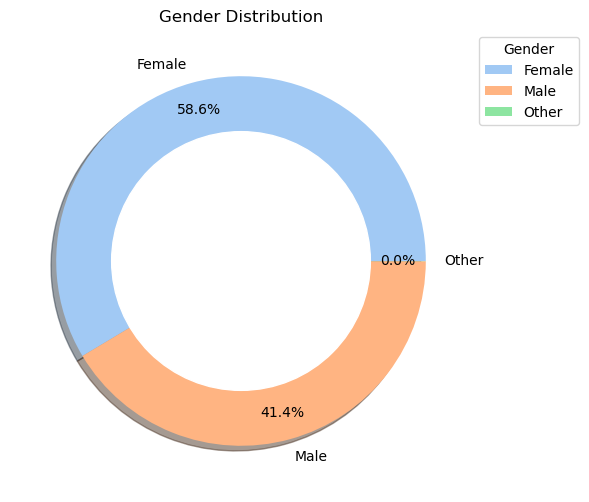

```python
# Calculate the count of each gender category and store it in a dictionary
gender_counts = dict(df['gender'].value_counts())

# Set a custom color palette for the pie chart
PALETTE = sns.color_palette("pastel")

# Create a new figure with a specified size
plt.figure(figsize=(10, 6))

# Set the title of the pie chart
plt.title("Gender Distribution")

# Create a pie chart with percentage labels, shadow effect, and custom colors
plt.pie(gender_counts.values(), labels=gender_counts.keys(), autopct="%.1f%%", pctdistance=0.85, shadow=True, colors=PALETTE)

# Add a legend with a title and adjust its position
plt.legend(title="Gender", labels=gender_counts.keys(), bbox_to_anchor=(1, 1))

# Add a white circle at the center to transform it into a donut chart
my_circle = plt.Circle((0, 0), 0.7, color='white')
plt.gcf().gca().add_artist(my_circle)

# Show the pie chart
plt.show()
```

#### Upon careful examination of the donut pie chart,The majority comprises females, accounting for 58.6%, while males constitute 41.4%. Notably, there is only one individual categorized as "Others."

### Count of Gender with 'ever_married' condition

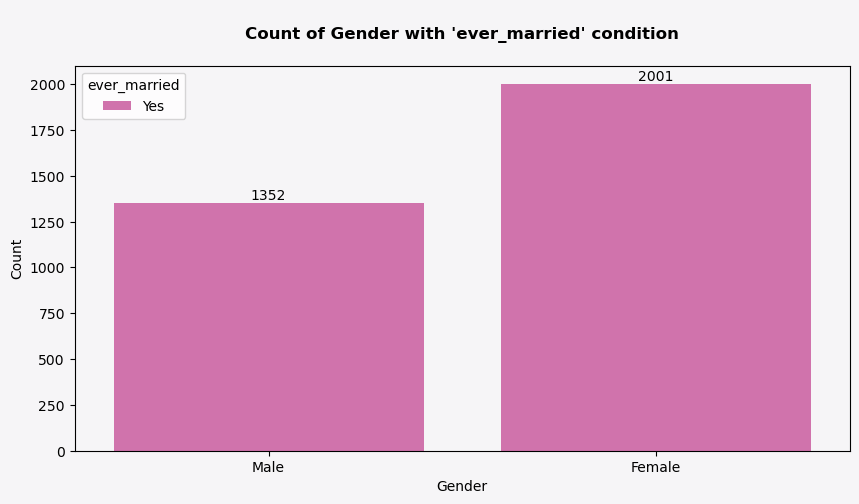

```python
# Create a figure and axes with a specified size
fig, ax = plt.subplots(figsize=(10, 5))

# Set the background color of the figure
fig.patch.set_facecolor('#f6f5f7')

# Set the background color of the axes
ax.set_facecolor('#f6f5f7')

# Filter the DataFrame to include only rows where 'ever_married' is "Yes"
ever_married_yes_df = df[df['ever_married'] == "Yes"]

# Create a count plot for 'gender' with the 'ever_married' condition
plot = sns.countplot(data=ever_married_yes_df, x="gender", palette='PuRd', hue='ever_married')

# Add labels with counts on top of the bars
for container in plot.containers:
    plot.bar_label(container)

# Set the x-axis label
plt.xlabel("Gender")

# Set the y-axis label
plt.ylabel("Count")

# Set the title of the plot
plt.title("\nCount of Gender with 'ever_married' condition\n", weight="bold")

# Show the plot
plt.show()
```

### Histogram for BMI and Age

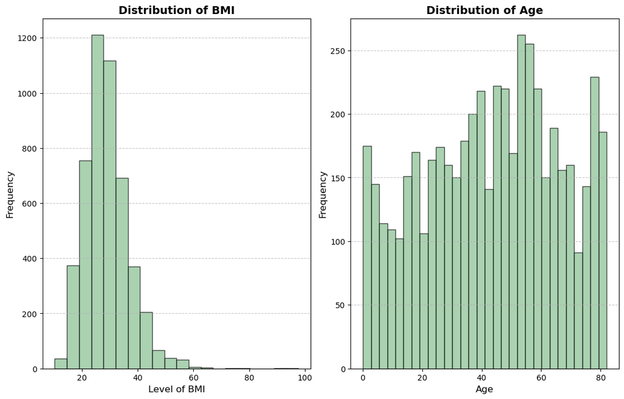

```python
# Create subplots with one row and two columns, and set the figure size
fig, axes = plt.subplots(1, 2, figsize=(11, 7), constrained_layout=True)

# Define a function for plotting a histogram with customized parameters
def plot_hist(data, bins=20, title='', xlabel='', ax=None):
    # Use the provided axes or create new ones if not provided
    ax = ax or plt.gca()

    # Plot the histogram
    ax.hist(data, bins=bins, color='#86bf91', edgecolor='black', alpha=0.7)

    # Set labels and title
    ax.set_title(title, fontsize=14, weight='bold')
    ax.set_xlabel(xlabel, fontsize=12)
    ax.set_ylabel('Frequency', fontsize=12)

    # Add grid for better readability
    ax.grid(axis='y', linestyle='--', alpha=0.7)

# Plot the histogram for BMI
plot_hist(df.bmi,
          title='Distribution of BMI',
          xlabel='Level of BMI',
          ax=axes[0])

# Plot the histogram for Age with custom bin count
plot_hist(df.age,
          bins=30,
          title='Distribution of Age',
          xlabel='Age',
          ax=axes[1])

# Show the plot
plt.show()
```

### Distribution of Work Type

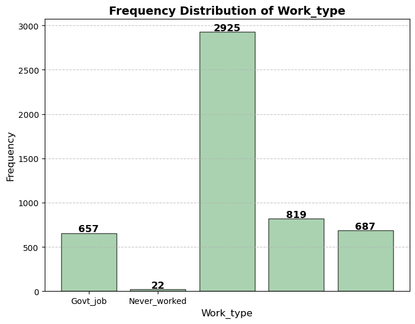

```python
# Specify the categorical column of interest
df_categorical_column = 'work_type'

# Get unique values and their counts in the specified categorical column
values, counts = np.unique(df[df_categorical_column], return_counts=True)

# Create a bar chart for the specified categorical column
plt.figure(figsize=(8, 6))
bars = plt.bar(values, counts, color='#86bf91', edgecolor='black', alpha=0.7)

# Set title, xlabel, and ylabel for the bar chart
plt.title(f'Frequency Distribution of {df_categorical_column.capitalize()}', fontsize=14, weight='bold')
plt.xlabel(df_categorical_column.capitalize(), fontsize=12)
plt.ylabel('Frequency', fontsize=12)

# Set x-axis ticks to 0 and 1
plt.xticks([0, 1])

# Add grid for better readability
plt.grid(axis='y', linestyle='--', alpha=0.7)

# Annotate the bars with the number of values
for bar, count in zip(bars, counts):
    plt.text(bar.get_x() + bar.get_width() / 2, bar.get_height() - 5,  # Adjusting the position
             str(count), ha='center', va='bottom', color='black', fontsize=12, fontweight='bold')

# Show the bar chart for the specified categorical column
plt.show()
```

### Distribution of heart disease

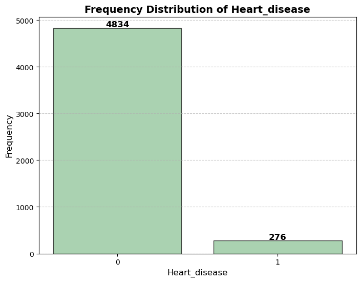

```python
# Specify the categorical column of interest
df_categorical_column = 'heart_disease'

# Get unique values and their counts in the specified categorical column
values, counts = np.unique(df[df_categorical_column], return_counts=True)

# Create a bar chart for the specified categorical column
plt.figure(figsize=(8, 6))
bars = plt.bar(values, counts, color='#86bf91', edgecolor='black', alpha=0.7)

# Set title, xlabel, and ylabel for the bar chart
plt.title(f'Frequency Distribution of {df_categorical_column.capitalize()}', fontsize=14, weight='bold')
plt.xlabel(df_categorical_column.capitalize(), fontsize=12)
plt.ylabel('Frequency', fontsize=12)

# Set x-axis ticks to 0 and 1
plt.xticks([0, 1])

# Add grid for better readability
plt.grid(axis='y', linestyle='--', alpha=0.7)

# Annotate the bars with the number of values
for bar, count in zip(bars, counts):
    plt.text(bar.get_x() + bar.get_width() / 2, bar.get_height() - 5,  # Adjusting the position
             str(count), ha='center', va='bottom', color='black', fontsize=12, fontweight='bold')

# Show the bar chart for the specified categorical column
plt.show()
```

### Distribution of hypertension

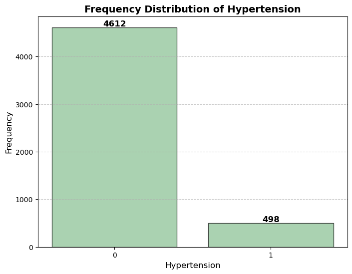

```python
# Specify the categorical column of interest
df_categorical_column = 'hypertension'

# Get unique values and their counts in the specified categorical column
values, counts = np.unique(df[df_categorical_column], return_counts=True)

# Create a bar chart for the specified categorical column
plt.figure(figsize=(8, 6))
bars = plt.bar(values, counts, color='#86bf91', edgecolor='black', alpha=0.7)

# Set title, xlabel, and ylabel for the bar chart
plt.title(f'Frequency Distribution of {df_categorical_column.capitalize()}', fontsize=14, weight='bold')
plt.xlabel(df_categorical_column.capitalize(), fontsize=12)
plt.ylabel('Frequency', fontsize=12)

# Set x-axis ticks to 0 and 1
plt.xticks([0, 1])

# Add grid for better readability
plt.grid(axis='y', linestyle='--', alpha=0.7)

# Annotate the bars with the number of values
for bar, count in zip(bars, counts):
    plt.text(bar.get_x() + bar.get_width() / 2, bar.get_height() - 5,  # Adjusting the position
             str(count), ha='center', va='bottom', color='black', fontsize=12, fontweight='bold')

# Show the bar chart for the specified categorical column
plt.show()
```

### Distribution of Residence type

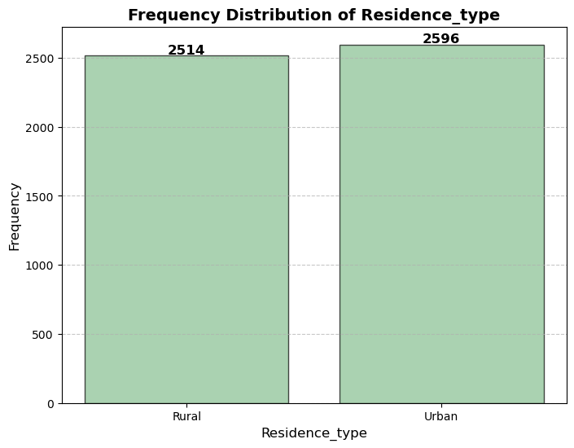

```python
# Specify the categorical column of interest
df_categorical_column = 'Residence_type'

# Get unique values and their counts in the specified categorical column
values, counts = np.unique(df[df_categorical_column], return_counts=True)

# Create a bar chart for the specified categorical column
plt.figure(figsize=(8, 6))
bars = plt.bar(values, counts, color='#86bf91', edgecolor='black', alpha=0.7)

# Set title, xlabel, and ylabel for the bar chart
plt.title(f'Frequency Distribution of {df_categorical_column.capitalize()}', fontsize=14, weight='bold')
plt.xlabel(df_categorical_column.capitalize(), fontsize=12)
plt.ylabel('Frequency', fontsize=12)

# Set x-axis ticks to 0 and 1
plt.xticks([0, 1])

# Add grid for better readability
plt.grid(axis='y', linestyle='--', alpha=0.7)

# Annotate the bars with the number of values
for bar, count in zip(bars, counts):
    plt.text(bar.get_x() + bar.get_width() / 2, bar.get_height() - 5,  # Adjusting the position
             str(count), ha='center', va='bottom', color='black', fontsize=12, fontweight='bold')

# Show the bar chart for the specified categorical column
plt.show()
```

### Distribution of Smoking status

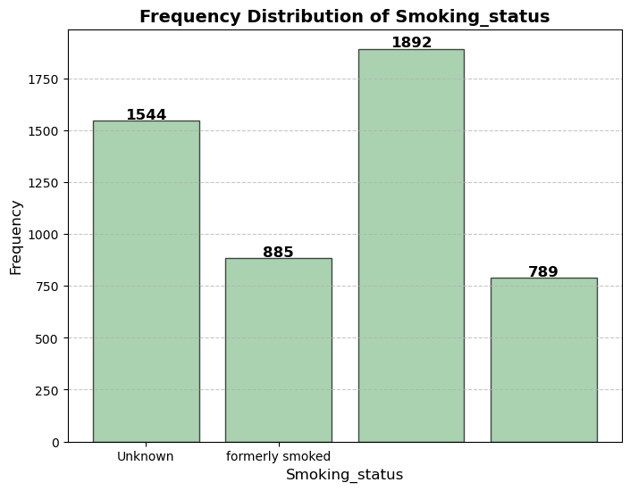

```python
# Specify the categorical column of interest
df_categorical_column = 'smoking_status'

# Get unique values and their counts in the specified categorical column
values, counts = np.unique(df[df_categorical_column], return_counts=True)

# Create a bar chart for the specified categorical column
plt.figure(figsize=(8, 6))
bars = plt.bar(values, counts, color='#86bf91', edgecolor='black', alpha=0.7)

# Set title, xlabel, and ylabel for the bar chart
plt.title(f'Frequency Distribution of {df_categorical_column.capitalize()}', fontsize=14, weight='bold')
plt.xlabel(df_categorical_column.capitalize(), fontsize=12)
plt.ylabel('Frequency', fontsize=12)

# Set x-axis ticks to 0 and 1
plt.xticks([0, 1])

# Add grid for better readability
plt.grid(axis='y', linestyle='--', alpha=0.7)

# Annotate the bars with the number of values
for bar, count in zip(bars, counts):
    plt.text(bar.get_x() + bar.get_width() / 2, bar.get_height() - 5,  # Adjusting the position
             str(count), ha='center', va='bottom', color='black', fontsize=12, fontweight='bold')

# Show the bar chart for the specified categorical column
plt.show()
```

### Distribution of Avg glucose level

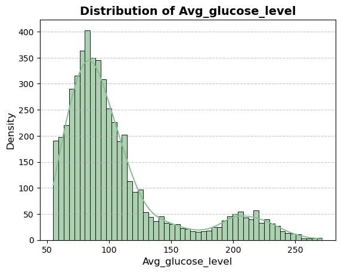

```python
# Specify the continuous column of interest
df_continuous_column = 'avg_glucose_level'

# Create a histogram with KDE for the specified continuous column using Seaborn
sns.histplot(df[df_continuous_column], kde=True, color='#86bf91', edgecolor='black', alpha=0.7)

# Set title, xlabel, and ylabel for the plot
plt.title(f'Distribution of {df_continuous_column.capitalize()}', fontsize=14, weight='bold')
plt.xlabel(df_continuous_column.capitalize(), fontsize=12)
plt.ylabel('Density', fontsize=12)  # Updated ylabel to represent density

# Add grid for better readability
plt.grid(axis='y', linestyle='--', alpha=0.7)

# Show the plot for the specified continuous column
plt.show()
```

### Correlation Matrix

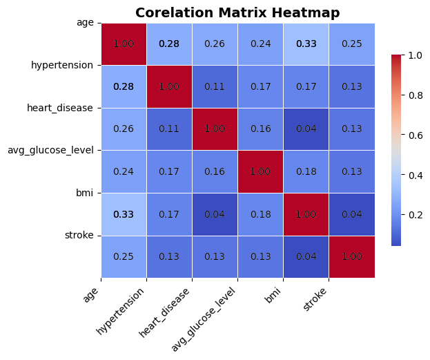

```python
# List of numerical columns in the DataFrame
df_numerical = ['age', 'hypertension', 'heart_disease', 'avg_glucose_level', 'bmi', 'stroke']

# Extract numeric columns from the DataFrame
numeric_columns = df[df_numerical]

# Calculate the correlation matrix for the numeric columns
corr_matrix = numeric_columns.corr()

# Create a heatmap of the correlation matrix using Seaborn
sns.heatmap(corr_matrix, cmap='coolwarm', annot=True, fmt=".2f", linewidths=.5, cbar_kws={"shrink": 0.75})

# Iterate through the cells in the correlation matrix to add numerical annotations
for i in range(len(corr_matrix)):
    for j in range(len(corr_matrix)):
        text = '{:.2f}'.format(corr_matrix.iloc[i, j])
        plt.text(j + 0.5, i + 0.5, text, ha='center', va='center', color='black', fontsize=10)

# Set x-axis and y-axis ticks and labels
plt.xticks(range(len(corr_matrix.columns)), corr_matrix.columns, rotation=45, ha='right')
plt.yticks(range(len(corr_matrix.columns)), corr_matrix.columns, rotation=0)

# Set title for the heatmap
plt.title("Corelation Matrix Heatmap", fontsize=14, weight='bold')

# Show the improved heatmap
plt.show()
```

#### Check the distribution of the target column

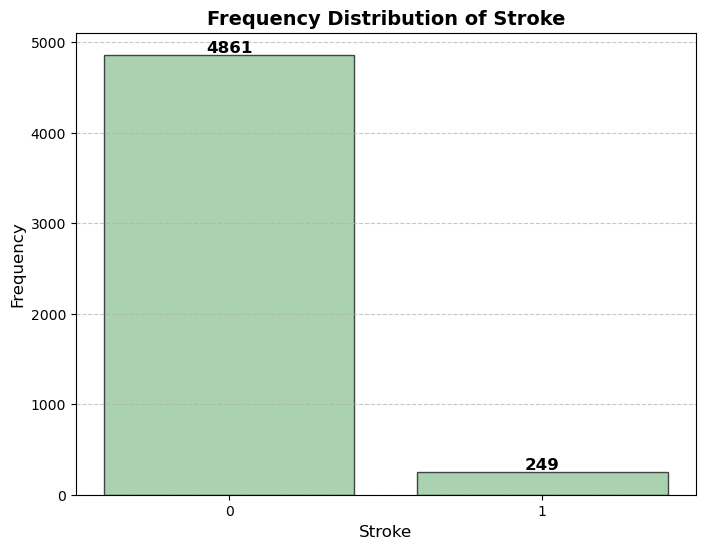

```python
# Specify the categorical column of interest
df_categorical_column = 'stroke'

# Get unique values and their counts in the specified categorical column
values, counts = np.unique(df[df_categorical_column], return_counts=True)

# Create a bar chart for the specified categorical column
plt.figure(figsize=(8, 6))
bars = plt.bar(values, counts, color='#86bf91', edgecolor='black', alpha=0.7)

# Set title, xlabel, and ylabel for the bar chart
plt.title(f'Frequency Distribution of {df_categorical_column.capitalize()}', fontsize=14, weight='bold')
plt.xlabel(df_categorical_column.capitalize(), fontsize=12)
plt.ylabel('Frequency', fontsize=12)

# Set x-axis ticks to 0 and 1
plt.xticks([0, 1])

# Add grid for better readability
plt.grid(axis='y', linestyle='--', alpha=0.7)

# Annotate the bars with the number of values
for bar, count in zip(bars, counts):
    plt.text(bar.get_x() + bar.get_width() / 2, bar.get_height() - 5,  # Adjusting the position
             str(count), ha='center', va='bottom', color='black', fontsize=12, fontweight='bold')

# Show the bar chart for the specified categorical column
plt.show()
```

### The dataset has been visualized, and the following columns were found to be imbalanced:

#### 1. Hypertension: 90.25% of the records indicate no hypertension.

#### 2. Heart Disease: 94.6% of the records indicate no heart disease.

#### 3. Stroke: 95.1% of the records indicate no stroke.

### These columns have a high proportion of a single class, making them imbalanced.

# 3 - DATA PRE-PROCESSING AND CLEANING

### Dealing With Single Value in gender column

```python
df.gender[df['gender']=='Other'].count()
```

```
1
```

#### Here we can see that only one value with other gender. we simply drop this value to improve our model accuracy

```python
df.drop(df[df['gender']=='Other'].index,axis = 0,inplace=True)
```

```python
df.gender[df['gender']=='Other'].count()
```

```
0
```

### Replace missing values with the mean

```python
# Replace missing values (NaN) in the 'bmi' column with the mean of the non-missing values
mean_bmi = df["bmi"].mean()  # Calculate the mean of the 'bmi' column
df["bmi"].fillna(mean_bmi, inplace=True)  # Replace missing values with the calculated mean
```

#### This approach helps to handle missing data by imputing the mean, maintaining the overall distribution.

### Again Check for missing values

```python
# Check for missing values in each column and sum them up
missing_values = df.isna().sum()

# Display the count of missing values for each column
print("Missing Values per Column:")
print(missing_values)
```

```
Missing Values per Column:
id                   0
gender               0
age                  0
hypertension         0
heart_disease        0
ever_married         0
work_type            0
Residence_type       0
avg_glucose_level    0
bmi                  0
smoking_status       0
stroke               0
dtype: int64
```

#### After replacing missing values we check again for missing values in dataset. Now, There is zero missing values in each column.

### Encoding

```python
# Replace categorical values with numerical equivalents
df['gender'].replace({'Male': 1, 'Female': 0}, inplace=True)
df.replace({'Yes': 1, 'No': 0}, inplace=True)
df['Residence_type'].replace({'Urban': 1, 'Rural': 0}, inplace=True)
```

```python
# One-Hot Encoding for work_type and smoking_status
df_encoded = pd.get_dummies(df, drop_first=True)
```

```python
df_encoded
```

|  | id | gender | age | hypertension | heart_disease | ever_married | Residence_type | avg_glucose_level | bmi | stroke | work_type_Never_worked | work_type_Private | work_type_Self-employed | work_type_children | smoking_status_formerly smoked | smoking_status_never smoked | smoking_status_smokes |
| --- | --- | --- | --- | --- | --- | --- | --- | --- | --- | --- | --- | --- | --- | --- | --- | --- | --- |
| 0 | 9046 | 1 | 67.0 | 0 | 1 | 1 | 1 | 228.69 | 36.60000 | 1 | 0 | 1 | 0 | 0 | 1 | 0 | 0 |
| 1 | 51676 | 0 | 61.0 | 0 | 0 | 1 | 0 | 202.21 | 28.89456 | 1 | 0 | 0 | 1 | 0 | 0 | 1 | 0 |
| 2 | 31112 | 1 | 80.0 | 0 | 1 | 1 | 0 | 105.92 | 32.50000 | 1 | 0 | 1 | 0 | 0 | 0 | 1 | 0 |
| 3 | 60182 | 0 | 49.0 | 0 | 0 | 1 | 1 | 171.23 | 34.40000 | 1 | 0 | 1 | 0 | 0 | 0 | 0 | 1 |
| 4 | 1665 | 0 | 79.0 | 1 | 0 | 1 | 0 | 174.12 | 24.00000 | 1 | 0 | 0 | 1 | 0 | 0 | 1 | 0 |
| ... | ... | ... | ... | ... | ... | ... | ... | ... | ... | ... | ... | ... | ... | ... | ... | ... | ... |
| 5105 | 18234 | 0 | 80.0 | 1 | 0 | 1 | 1 | 83.75 | 28.89456 | 0 | 0 | 1 | 0 | 0 | 0 | 1 | 0 |
| 5106 | 44873 | 0 | 81.0 | 0 | 0 | 1 | 1 | 125.20 | 40.00000 | 0 | 0 | 0 | 1 | 0 | 0 | 1 | 0 |
| 5107 | 19723 | 0 | 35.0 | 0 | 0 | 1 | 0 | 82.99 | 30.60000 | 0 | 0 | 0 | 1 | 0 | 0 | 1 | 0 |
| 5108 | 37544 | 1 | 51.0 | 0 | 0 | 1 | 0 | 166.29 | 25.60000 | 0 | 0 | 1 | 0 | 0 | 1 | 0 | 0 |
| 5109 | 44679 | 0 | 44.0 | 0 | 0 | 1 | 1 | 85.28 | 26.20000 | 0 | 0 | 0 | 0 | 0 | 0 | 0 | 0 |

5109 rows × 17 columns

### Balancing the dataset

```python
from imblearn.over_sampling import SMOTE

# Separate features and target variable
X = df_encoded.drop(columns=['stroke'])
y = df_encoded['stroke']

# Apply SMOTE to balance the 'stroke' column
smote = SMOTE(random_state=42)
X_resampled, y_resampled = smote.fit_resample(X, y)

# Convert the resampled dataset back to DataFrame
X_resampled_df = pd.DataFrame(X_resampled, columns=X.columns)
y_resampled_df = pd.DataFrame(y_resampled, columns=['stroke'])

# Combine the features and target variable
resampled_data = pd.concat([X_resampled_df, y_resampled_df], axis=1)

# Manually balance 'hypertension' and 'heart_disease' columns
for column in ['hypertension', 'heart_disease']:
    max_samples = resampled_data[column].value_counts().max()
    balanced_data = pd.DataFrame()
    for class_value in resampled_data[column].unique():
        class_data = resampled_data[resampled_data[column] == class_value]
        balanced_class_data = class_data.sample(max_samples, replace=True, random_state=42)
        balanced_data = pd.concat([balanced_data, balanced_class_data], axis=0)
    resampled_data = balanced_data

# Shuffle the dataset to mix the classes
resampled_data = resampled_data.sample(frac=1, random_state=42).reset_index(drop=True)

# Save the balanced dataset to a CSV file
balanced_file_path = 'healthcare-dataset-stroke-data-balanced.csv'
resampled_data.to_csv(balanced_file_path, index=False)

print(f"Balanced dataset saved to {balanced_file_path}")
```

```
Balanced dataset saved to healthcare-dataset-stroke-data-balanced.csv
```

### Now, Loading and reading balanced dataset

```python
# Load the dataset into a Pandas DataFrame
df = pd.read_csv("healthcare-dataset-stroke-data-balanced.csv")
```

```python
df.head()
```

|  | id | gender | age | hypertension | heart_disease | ever_married | Residence_type | avg_glucose_level | bmi | work_type_Never_worked | work_type_Private | work_type_Self-employed | work_type_children | smoking_status_formerly smoked | smoking_status_never smoked | smoking_status_smokes | stroke |
| --- | --- | --- | --- | --- | --- | --- | --- | --- | --- | --- | --- | --- | --- | --- | --- | --- | --- |
| 0 | 29314 | 0 | 73.000000 | 1 | 1 | 1 | 1 | 67.380000 | 32.800000 | 0 | 0 | 0 | 0 | 1 | 0 | 0 | 0 |
| 1 | 38605 | 0 | 36.000000 | 0 | 0 | 1 | 0 | 101.930000 | 22.800000 | 0 | 1 | 0 | 0 | 0 | 0 | 1 | 0 |
| 2 | 53581 | 1 | 72.123700 | 1 | 1 | 0 | 0 | 161.934902 | 29.589017 | 0 | 0 | 0 | 0 | 0 | 1 | 0 | 1 |
| 3 | 2350 | 0 | 71.165737 | 0 | 0 | 1 | 0 | 155.254115 | 27.721297 | 0 | 0 | 0 | 0 | 0 | 0 | 0 | 1 |
| 4 | 35069 | 0 | 50.000000 | 1 | 1 | 0 | 1 | 79.790000 | 25.600000 | 0 | 0 | 0 | 0 | 0 | 0 | 1 | 0 |

```python
df.info()
```

```
<class 'pandas.core.frame.DataFrame'>
RangeIndex: 33264 entries, 0 to 33263
Data columns (total 17 columns):
 #   Column                          Non-Null Count  Dtype
---  ------                          --------------  -----
 0   id                              33264 non-null  int64
 1   gender                          33264 non-null  int64
 2   age                             33264 non-null  float64
 3   hypertension                    33264 non-null  int64
 4   heart_disease                   33264 non-null  int64
 5   ever_married                    33264 non-null  int64
 6   Residence_type                  33264 non-null  int64
 7   avg_glucose_level               33264 non-null  float64
 8   bmi                             33264 non-null  float64
 9   work_type_Never_worked          33264 non-null  int64
 10  work_type_Private               33264 non-null  int64
 11  work_type_Self-employed         33264 non-null  int64
 12  work_type_children              33264 non-null  int64
 13  smoking_status_formerly smoked  33264 non-null  int64
 14  smoking_status_never smoked     33264 non-null  int64
 15  smoking_status_smokes           33264 non-null  int64
 16  stroke                          33264 non-null  int64
dtypes: float64(3), int64(14)
memory usage: 4.3 MB
```

### Again Visualizing the imbalanced columns

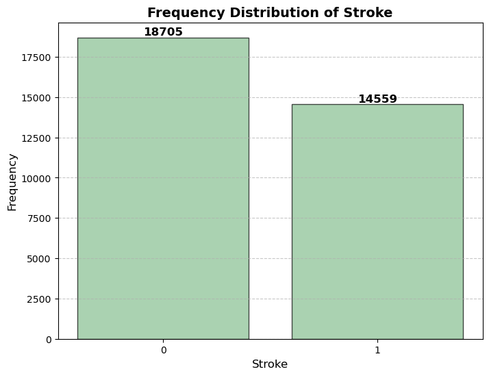

```python
# Specify the categorical column of interest
df_categorical_column = 'stroke'

# Get unique values and their counts in the specified categorical column
values, counts = np.unique(df[df_categorical_column], return_counts=True)

# Create a bar chart for the specified categorical column
plt.figure(figsize=(8, 6))
bars = plt.bar(values, counts, color='#86bf91', edgecolor='black', alpha=0.7)

# Set title, xlabel, and ylabel for the bar chart
plt.title(f'Frequency Distribution of {df_categorical_column.capitalize()}', fontsize=14, weight='bold')
plt.xlabel(df_categorical_column.capitalize(), fontsize=12)
plt.ylabel('Frequency', fontsize=12)

# Set x-axis ticks to 0 and 1
plt.xticks([0, 1])

# Add grid for better readability
plt.grid(axis='y', linestyle='--', alpha=0.7)

# Annotate the bars with the number of values
for bar, count in zip(bars, counts):
    plt.text(bar.get_x() + bar.get_width() / 2, bar.get_height() - 5,  # Adjusting the position
             str(count), ha='center', va='bottom', color='black', fontsize=12, fontweight='bold')

# Show the bar chart for the specified categorical column
plt.show()
```

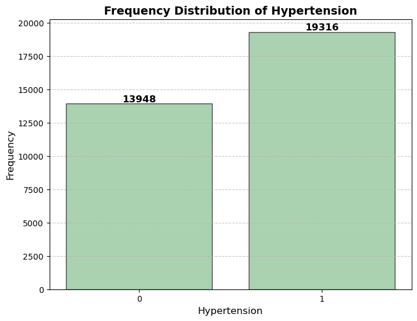

```python
# Specify the categorical column of interest
df_categorical_column = 'hypertension'

# Get unique values and their counts in the specified categorical column
values, counts = np.unique(df[df_categorical_column], return_counts=True)

# Create a bar chart for the specified categorical column
plt.figure(figsize=(8, 6))
bars = plt.bar(values, counts, color='#86bf91', edgecolor='black', alpha=0.7)

# Set title, xlabel, and ylabel for the bar chart
plt.title(f'Frequency Distribution of {df_categorical_column.capitalize()}', fontsize=14, weight='bold')
plt.xlabel(df_categorical_column.capitalize(), fontsize=12)
plt.ylabel('Frequency', fontsize=12)

# Set x-axis ticks to 0 and 1
plt.xticks([0, 1])

# Add grid for better readability
plt.grid(axis='y', linestyle='--', alpha=0.7)

# Annotate the bars with the number of values
for bar, count in zip(bars, counts):
    plt.text(bar.get_x() + bar.get_width() / 2, bar.get_height() - 5,  # Adjusting the position
             str(count), ha='center', va='bottom', color='black', fontsize=12, fontweight='bold')

# Show the bar chart for the specified categorical column
plt.show()
```

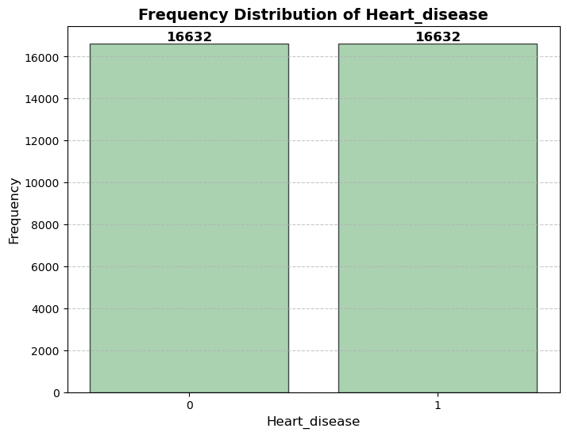

```python
# Specify the categorical column of interest
df_categorical_column = 'heart_disease'

# Get unique values and their counts in the specified categorical column
values, counts = np.unique(df[df_categorical_column], return_counts=True)

# Create a bar chart for the specified categorical column
plt.figure(figsize=(8, 6))
bars = plt.bar(values, counts, color='#86bf91', edgecolor='black', alpha=0.7)

# Set title, xlabel, and ylabel for the bar chart
plt.title(f'Frequency Distribution of {df_categorical_column.capitalize()}', fontsize=14, weight='bold')
plt.xlabel(df_categorical_column.capitalize(), fontsize=12)
plt.ylabel('Frequency', fontsize=12)

# Set x-axis ticks to 0 and 1
plt.xticks([0, 1])

# Add grid for better readability
plt.grid(axis='y', linestyle='--', alpha=0.7)

# Annotate the bars with the number of values
for bar, count in zip(bars, counts):
    plt.text(bar.get_x() + bar.get_width() / 2, bar.get_height() - 5,  # Adjusting the position
             str(count), ha='center', va='bottom', color='black', fontsize=12, fontweight='bold')

# Show the bar chart for the specified categorical column
plt.show()
```

# 4 - FEATURE SELECTION AND ENGINEERING

### Recursive Feature Elimination (RFE)

```python
# Define the estimator model
estimator = LogisticRegression()

# Number of top features to select
k = 13

# Initialize RFE with the estimator and the number of features to select
rfe_selector = RFE(estimator, n_features_to_select=k, step=1)

# Fit RFE on the data
X_rfe_selected = rfe_selector.fit_transform(X, y)

# Get the selected feature indices
selected_feature_indices_rfe = rfe_selector.get_support(indices=True)

# Get the names of the selected features
selected_features_rfe = X.columns[selected_feature_indices_rfe]

print("Selected Features using RFE:")
print(selected_features_rfe)
```

```
Selected Features using RFE:
Index(['gender', 'age', 'hypertension', 'heart_disease', 'ever_married',
       'Residence_type', 'work_type_Never_worked', 'work_type_Private',
       'work_type_Self-employed', 'work_type_children',
       'smoking_status_formerly smoked', 'smoking_status_never smoked',
       'smoking_status_smokes'],
      dtype='object')
```

#### The Recursive Feature Elimination (RFE) method is employed to select the most significant features for model training. RFE is a model-based method that recursively removes the least important features based on the estimator model's weights. In this case, logistic regression is used as the estimator model. Which gives top 13 features that will be later used for model training. Selected features are 'age', 'hypertension', 'heart_disease', 'gender', 'ever_married','Residence_type', 'work_type_Never_worked', 'work_type_Private','work_type_Self-employed', 'work_type_children','smoking_status_formerly smoked', 'smoking_status_never smoked','smoking_status_smokes'.

### ANOVA

```python
# Identify numerical columns
numerical_columns = [
    'id', 'age', 'hypertension', 'heart_disease', 'avg_glucose_level', 'bmi',
    'gender', 'ever_married', 'Residence_type', 'work_type_Never_worked',
    'work_type_Private', 'work_type_Self-employed', 'work_type_children',
    'smoking_status_formerly smoked', 'smoking_status_never smoked',
    'smoking_status_smokes'
]

# Separate features and target variable
X = df[numerical_columns]
y = df['stroke']

# Feature selection using ANOVA for numerical features
k = 13  # Number of top features to select
anova_selector = SelectKBest(f_classif, k=k)
X_anova_selected = anova_selector.fit_transform(X, y)

# Get the selected feature indices
selected_feature_indices = anova_selector.get_support(indices=True)

# Get the names of the selected features
selected_features = X.columns[selected_feature_indices]

print("Selected Features:")
print(selected_features)
```

```
Selected Features:
Index(['age', 'hypertension', 'heart_disease', 'avg_glucose_level', 'gender',
       'ever_married', 'Residence_type', 'work_type_Private',
       'work_type_Self-employed', 'work_type_children',
       'smoking_status_formerly smoked', 'smoking_status_never smoked',
       'smoking_status_smokes'],
      dtype='object')
```

#### ANOVA (Analysis of Variance) feature selection is typically used when dealing with numerical features. We use ANOVA feature selection method for categorical columns. Which gives top 13 features that will be later used for model training. Selected features are 'age', 'hypertension', 'heart_disease', 'avg_glucose_level', 'gender','ever_married', 'Residence_type', 'work_type_Private','work_type_Self-employed', 'work_type_children','smoking_status_formerly smoked', 'smoking_status_never smoked','smoking_status_smokes''.

# 5 & 6 - MODEL IMPLEMENTATION, EVALUATION AND TRAINING

### Spiliting Dataset into Train & Test

```python
# Define the features to be used for prediction
features = ['age', 'hypertension', 'heart_disease', 'gender', 'ever_married','Residence_type', 'avg_glucose_level','work_type_Never_worked',
            'work_type_Private', 'work_type_Self-employed', 'work_type_children', 'smoking_status_formerly smoked', 'smoking_status_never smoked',
            'smoking_status_smokes']

# Extract the selected features (X) and the target variable (Y) from the DataFrame
X = df[features]
Y = df['stroke']

# Convert categorical variables to numerical using LabelEncoder
label_encoder = LabelEncoder()
for column in X.columns:
    if X[column].dtype == 'object':
        X[column] = label_encoder.fit_transform(X[column])

# Perform train-test split on the feature set (X) and target variable (Y)
X_train, X_test, Y_train, Y_test = train_test_split(X, Y,random_state=65, test_size=0.2)

# Print the shape of the training feature set (X_train)
print("Training feature set shape:", X_train.shape)

# Print the shape of the testing feature set (X_test)
print("Testing feature set shape:", X_test.shape)

# Print the shape of the training target variable (Y_train)
print("Training target variable shape:", Y_train.shape)

# Print the shape of the testing target variable (Y_test)
print("Testing target variable shape:", Y_test.shape)
```

```
Training feature set shape: (26611, 14)
Testing feature set shape: (6653, 14)
Training target variable shape: (26611,)
Testing target variable shape: (6653,)
```

### Random Forest Classifier

#### Train the Random Forest Classifier model

```python
# Record the start time for training
start_time_rf = time.time()

# Create an instance of the RandomForestClassifier with specified parameters
rf_classifier = RandomForestClassifier(n_estimators=100, random_state=42)

# Train (fit) the RandomForestClassifier on the training data (features: X_train, target variable: Y_train)
rf_classifier.fit(X_train, Y_train)

# Calculate the training time
training_time_rf = time.time() - start_time_rf
print(f"Training time (RandomForestClassifier): {training_time_rf:.4f} seconds")

# Print a message indicating that the RandomForestClassifier has been trained successfully
print("Random Forest Classifier trained successfully!")
```

```
Training time (RandomForestClassifier): 2.7926 seconds
Random Forest Classifier trained successfully!
```

#### Evaluate the Random Forest Classifier model

```python
# Make predictions on the test set using the trained RandomForestClassifier
Y_pred_rf = rf_classifier.predict(X_test)

# Calculate the accuracy of the model by comparing predicted and actual values
accuracy_rf = accuracy_score(Y_test, Y_pred_rf)

# Generate the confusion matrix to evaluate the performance of the classification model
confusion = confusion_matrix(Y_test, Y_pred_rf)

# Generate a classification report, including precision, recall, and F1-score
classification_rep = classification_report(Y_test, Y_pred_rf)

# Save the sample results to a CSV file
sample_results = pd.DataFrame({'True Outcome': Y_test, 'Predicted Outcome': Y_pred_rf})
sample_results.to_csv('RF_sample_results.csv', index=False)

# Print the accuracy of the model
print("Accuracy (RandomForestClassifier) :", accuracy_rf)

# Print the confusion matrix
print("Confusion Matrix (RandomForestClassifier) :\n", confusion)

# Print the classification report
print("Classification Report (RandomForestClassifier) :\n", classification_rep)
```

```
Accuracy (RandomForestClassifier) : 0.9944385991282129
Confusion Matrix (RandomForestClassifier) :
 [[3659   25]
 [  12 2957]]
Classification Report (RandomForestClassifier) :
               precision    recall  f1-score   support

           0       1.00      0.99      0.99      3684
           1       0.99      1.00      0.99      2969

    accuracy                           0.99      6653
   macro avg       0.99      0.99      0.99      6653
weighted avg       0.99      0.99      0.99      6653
```

### K-Nearest Neighbors Classifier (KNN)

#### Train the K-Nearest Neighbors Classifier model

```python
# Record the start time for training
start_time_knn = time.time()

# Create an instance of the KNeighborsClassifier with specified parameters
knn_classifier = KNeighborsClassifier(n_neighbors=5)

# Train (fit) the KNeighborsClassifier on the training data (features: X_train, target variable: Y_train)
knn_classifier.fit(X_train, Y_train)

# Calculate the training time
training_time_knn = time.time() - start_time_knn
print(f"Training time (KNeighborsClassifier): {training_time_knn:.4f} seconds")

# Print a message indicating that the KNeighborsClassifier has been trained successfully
print("K-Nearest Neighbors Classifier trained successfully!")
```

```
Training time (KNeighborsClassifier): 0.2995 seconds
K-Nearest Neighbors Classifier trained successfully!
```

#### Evaluate the K-Nearest Neighbors Classifier model

```python
# Make predictions on the test set using the trained KNeighborsClassifier
Y_pred_knn = knn_classifier.predict(X_test)

# Calculate the accuracy of the model by comparing predicted and actual values
accuracy_knn = accuracy_score(Y_test, Y_pred_knn)

# Generate the confusion matrix to evaluate the performance of the classification model
confusion_knn = confusion_matrix(Y_test, Y_pred_knn)

# Generate a classification report, including precision, recall, and F1-score
classification_rep_knn = classification_report(Y_test, Y_pred_knn)

# Save the sample results to a CSV file
sample_results = pd.DataFrame({'True Outcome': Y_test, 'Predicted Outcome': Y_pred_knn})
sample_results.to_csv('KNN_classifier_sample_results.csv', index=False)

# Print the accuracy of the model
print("Accuracy (KNN):", accuracy_knn)

# Print the confusion matrix
print("Confusion Matrix (KNN):\n", confusion_knn)

# Print the classification report
print("Classification Report (KNN):\n", classification_rep_knn)
```

```
Accuracy (KNN): 0.9684352923493161
Confusion Matrix (KNN):
 [[3568  116]
 [  94 2875]]
Classification Report (KNN):
               precision    recall  f1-score   support

           0       0.97      0.97      0.97      3684
           1       0.96      0.97      0.96      2969

    accuracy                           0.97      6653
   macro avg       0.97      0.97      0.97      6653
weighted avg       0.97      0.97      0.97      6653
```

### Decision Tree Classifier

#### Train the Decision Tree Classifier model

```python
# Record the start time for training
start_time_dt = time.time()

# Create an instance of the DecisionTreeClassifier with specified parameters
dt_classifier = DecisionTreeClassifier(random_state=42)

# Train (fit) the DecisionTreeClassifier on the training data (features: X_train, target variable: Y_train)
dt_classifier.fit(X_train, Y_train)

# Calculate the training time
training_time_dt = time.time() - start_time_dt
print(f"Training time (Decision Tree): {training_time_dt:.4f} seconds")

# Print a message indicating that the DecisionTreeClassifier has been trained successfully
print("Decision Tree Classifier trained successfully!")
```

```
Training time (Decision Tree): 0.1265 seconds
Decision Tree Classifier trained successfully!
```

#### Evaluate the Decision Tree Classifier model

```python
# Make predictions on the test set using the trained DecisionTreeClassifier
Y_pred_dt = dt_classifier.predict(X_test)

# Calculate the accuracy of the model by comparing predicted and actual values
accuracy_dt = accuracy_score(Y_test, Y_pred_dt)

# Generate the confusion matrix to evaluate the performance of the classification model
confusion_dt = confusion_matrix(Y_test, Y_pred_dt)

# Generate a classification report, including precision, recall, and F1-score
classification_rep_dt = classification_report(Y_test, Y_pred_dt)

# Save the sample results to a CSV file
sample_results = pd.DataFrame({'True Outcome': Y_test, 'Predicted Outcome': Y_pred_dt})
sample_results.to_csv('DT_classifier_sample_results.csv', index=False)

# Print the accuracy of the model
print("Accuracy (Decision Tree):", accuracy_dt)

# Print the confusion matrix
print("Confusion Matrix (Decision Tree):\n", confusion_dt)

# Print the classification report
print("Classification Report (Decision Tree):\n", classification_rep_dt)
```

```
Accuracy (Decision Tree): 0.992183977153164
Confusion Matrix (Decision Tree):
 [[3654   30]
 [  22 2947]]
Classification Report (Decision Tree):
               precision    recall  f1-score   support

           0       0.99      0.99      0.99      3684
           1       0.99      0.99      0.99      2969

    accuracy                           0.99      6653
   macro avg       0.99      0.99      0.99      6653
weighted avg       0.99      0.99      0.99      6653
```

### Logistic Regression Model

#### Train the Logistic Regression model

```python
# Create an instance of the Logistic Regression model with specified parameters
logreg_model = LogisticRegression(random_state=42)

# Record the start time for training
start_time_logreg = time.time()

# Train (fit) the Logistic Regression model on the training data (features: X_train, target variable: Y_train)
logreg_model.fit(X_train, Y_train)

# Calculate the training time
training_time_logreg = time.time() - start_time_logreg
print(f"Training time (Logistic Regression): {training_time_logreg:.4f} seconds")

# Print a message indicating that the Logistic Regression model has been trained successfully
print("Logistic Regression model trained successfully!")
```

```
Training time (Logistic Regression): 0.3298 seconds
Logistic Regression model trained successfully!
```

#### Evaluate the Logistic Regression model

```python
# Make predictions on the test set using the trained Logistic Regression model
Y_pred_logreg = logreg_model.predict(X_test)

# Calculate the accuracy of the model by comparing predicted and actual values
accuracy_logreg = accuracy_score(Y_test, Y_pred_logreg)

# Generate the confusion matrix to evaluate the performance of the classification model
confusion_logreg = confusion_matrix(Y_test, Y_pred_logreg)

# Generate a classification report, including precision, recall, and F1-score
classification_rep_logreg = classification_report(Y_test, Y_pred_logreg)

# Save the sample results to a CSV file
sample_results = pd.DataFrame({'True Outcome': Y_test, 'Predicted Outcome': Y_pred_logreg})
sample_results.to_csv('LogReg_model_sample_results.csv', index=False)

# Print the accuracy of the model
print("Accuracy (Logistic Regression):", accuracy_logreg)

# Print the confusion matrix
print("Confusion Matrix (Logistic Regression):\n", confusion_logreg)

# Print the classification report
print("Classification Report (Logistic Regression):\n", classification_rep_logreg)
```

```
Accuracy (Logistic Regression): 0.7952803246655644
Confusion Matrix (Logistic Regression):
 [[3056  628]
 [ 734 2235]]
Classification Report (Logistic Regression):
               precision    recall  f1-score   support

           0       0.81      0.83      0.82      3684
           1       0.78      0.75      0.77      2969

    accuracy                           0.80      6653
   macro avg       0.79      0.79      0.79      6653
weighted avg       0.79      0.80      0.79      6653
```

### Artificial Neural Network (ANN)

#### Standardize the features for ANN

```python
# Instantiate a StandardScaler object to normalize/standardize the features
scaler = StandardScaler()

# Fit the scaler to the training data and transform it, scaling the features to have mean 0 and variance 1
X_train_scaled = scaler.fit_transform(X_train)

# Use the already fitted scaler to transform the test data in the same way
X_test_scaled = scaler.transform(X_test)
```

#### Build the ANN model

```python
from tensorflow import keras

# Define a sequential model
model = keras.Sequential([
    # Add a dense (fully connected) layer with 30 neurons, input shape is (14,)
    # The input shape should match the number of features in your dataset
    keras.layers.Dense(30, input_shape=(14,), activation='relu'),  # First hidden layer with ReLU activation

    # Add a dense layer with 25 neurons and ReLU activation function
    keras.layers.Dense(25, activation='relu'),  # Second hidden layer with ReLU activation

    # Add a dense layer with 20 neurons and ReLU activation function
    keras.layers.Dense(20, activation='relu'),  # Third hidden layer with ReLU activation

    # Add a dense layer with 15 neurons and ReLU activation function
    keras.layers.Dense(15, activation='relu'),  # Fourth hidden layer with ReLU activation

    # Add a dense layer with 1 neuron and sigmoid activation function
    # This is the output layer, sigmoid is used for binary classification
    keras.layers.Dense(1, activation='sigmoid')  # Output layer with Sigmoid activation
])

# Compile the model with specified optimizer, loss function, and metrics
model.compile(optimizer='adam',  # Adam optimizer, an efficient version of gradient descent
              loss='binary_crossentropy',  # Binary crossentropy loss for binary classification
              metrics=['accuracy'])  # Track accuracy during training

# Print the summary of the model architecture
model.summary()  # Print the model summary to show the architecture
```

```
Model: "sequential"
_________________________________________________________________
 Layer (type)                Output Shape              Param #
=================================================================
 dense (Dense)               (None, 30)                450

 dense_1 (Dense)             (None, 25)                775

 dense_2 (Dense)             (None, 20)                520

 dense_3 (Dense)             (None, 15)                315

 dense_4 (Dense)             (None, 1)                 16

=================================================================
Total params: 2,076
Trainable params: 2,076
Non-trainable params: 0
_________________________________________________________________
```

#### Train the ANN model

```python
# Train the model for a fixed number of epochs
history = model.fit(X_train_scaled, Y_train,
                    epochs=100,
                    batch_size=32,
                    validation_data=(X_test_scaled, Y_test))
```

#### Saving the Model

```python
# Save the entire model
model.save('trained_ann_model.h5')
```

#### Evaluate the ANN model

```python
# Load the previously saved model
loaded_model = load_model('trained_ann_model.h5')

# Make predictions on the test set using the trained ANN model
Y_pred_ann = (loaded_model.predict(X_test_scaled) > 0.5).astype("int32")

# Calculate the accuracy of the model by comparing predicted and actual values
accuracy_ann = accuracy_score(Y_test, Y_pred_ann)

# Generate the confusion matrix to evaluate the performance of the classification model
confusion_ann = confusion_matrix(Y_test, Y_pred_ann)

# Generate a classification report, including precision, recall, and F1-score
classification_rep_ann = classification_report(Y_test, Y_pred_ann)

# Save the sample results to a CSV file
sample_results_ann = pd.DataFrame({'True Outcome': Y_test, 'Predicted Outcome': Y_pred_ann.flatten()})
sample_results_ann.to_csv('ANN_model_sample_results.csv', index=False)

# Print the accuracy of the model
print("Accuracy (Artificial Neural Network):", accuracy_ann)

# Print the confusion matrix
print("Confusion Matrix (Artificial Neural Network):\n", confusion_ann)

# Print the classification report
print("Classification Report (Artificial Neural Network):\n", classification_rep_ann)
```

```
Accuracy (Artificial Neural Network): 0.9873741169397264
Confusion Matrix (Artificial Neural Network):
 [[3636   48]
 [  36 2933]]
Classification Report (Artificial Neural Network):
               precision    recall  f1-score   support

           0       0.99      0.99      0.99      3684
           1       0.98      0.99      0.99      2969

    accuracy                           0.99      6653
   macro avg       0.99      0.99      0.99      6653
weighted avg       0.99      0.99      0.99      6653
```

# 7 - RESULTS VISUALIZATION AND ANALYSIS

### Random Forest Classifier

```
Sample Results:
       True Outcome  Predicted Outcome
5643             1                  1
3366             0                  0
573              1                  1
6039             1                  1
4240             0                  0
1176             1                  1
6276             1                  1
3356             1                  1
736              1                  1
1900             0                  0
```

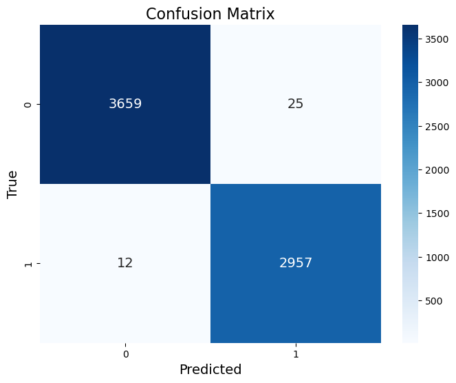

```python
# Read the sample results from the CSV file
sample_results = pd.read_csv('RF_sample_results.csv')

# Visualize the first few rows of the DataFrame
print("Sample Results:\n", sample_results.sample(10))

# Visualize the confusion matrix as a heatmap
confusion = confusion_matrix(sample_results['True Outcome'], sample_results['Predicted Outcome'])
plt.figure(figsize=(8, 6))
sns.heatmap(confusion, annot=True, fmt='d', cmap='Blues', annot_kws={'size': 14})
plt.title('Confusion Matrix', fontsize=16)
plt.xlabel('Predicted', fontsize=14)
plt.ylabel('True', fontsize=14)
plt.show()


# Discuss the strengths and limitations of the implemented model
# Emphasize interpretability and implications of the model
```

#### The Random Forest Classifier achieved an outstanding accuracy of 99.44%, indicating robust predictive performance across the dataset. The confusion matrix reveals that the model correctly predicted the majority of instances for both classes. Specifically, it correctly classified 3659 instances of class 0 (No) and 2957 instances of class 1 (Yes).

#### The precision, recall, and F1-score for both classes are also very high, reflecting the model's balanced performance in predicting both positive and negative instances. This evaluation suggests that the Random Forest Classifier is highly effective for this particular dataset, with very few misclassifications.

### K-Nearest Neighbors Classifier (KNN)

```
KNN Sample Results:
       True Outcome  Predicted Outcome
3829             0                  0
6274             0                  0
3986             0                  0
2940             0                  0
1319             1                  1
4359             1                  1
471              0                  0
5118             1                  1
2616             1                  1
3918             0                  0
```

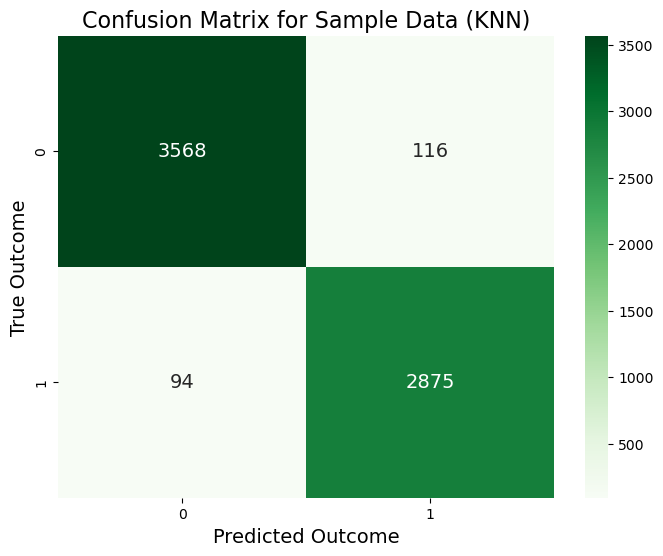

```python
# Read the sample results from the CSV file
sample_results_knn = pd.read_csv('KNN_classifier_sample_results.csv')

# Visualize the first few rows of the DataFrame
print("KNN Sample Results:\n", sample_results_knn.sample(10))

# Visualize the confusion matrix as a heatmap for the sample data (KNN)
confusion_knn = confusion_matrix(sample_results_knn['True Outcome'], sample_results_knn['Predicted Outcome'])
plt.figure(figsize=(8, 6))
sns.heatmap(confusion_knn, annot=True, fmt='d', cmap='Greens', annot_kws={'size': 14})
plt.title('Confusion Matrix for Sample Data (KNN)', fontsize=16)
plt.xlabel('Predicted Outcome', fontsize=14)
plt.ylabel('True Outcome', fontsize=14)
plt.show()

# Discuss the strengths and limitations of the implemented KNN model on the sample data
# Emphasize interpretability and implications of the model
```

#### The K-Nearest Neighbors (KNN) Classifier demonstrated a strong accuracy of 96.84%, indicating reliable predictive performance across the dataset. The confusion matrix reveals that the model correctly predicted the majority of instances for both classes, with 3568 correct predictions for class 0 (No) and 2875 correct predictions for class 1 (Yes).

#### The precision, recall, and F1-score for both classes are consistently high, showing the model's balanced performance in predicting both positive and negative instances. Overall, the KNN classifier is highly effective for this dataset, with minimal misclassifications, indicating its suitability for the task at hand.

### Decision Tree Classifier

```
Decision Tree Sample Results:
       True Outcome  Predicted Outcome
6286             1                  1
5185             0                  0
2960             0                  0
5409             0                  0
3788             0                  0
5788             1                  1
214              0                  0
1146             0                  0
3151             1                  1
3022             0                  0
```

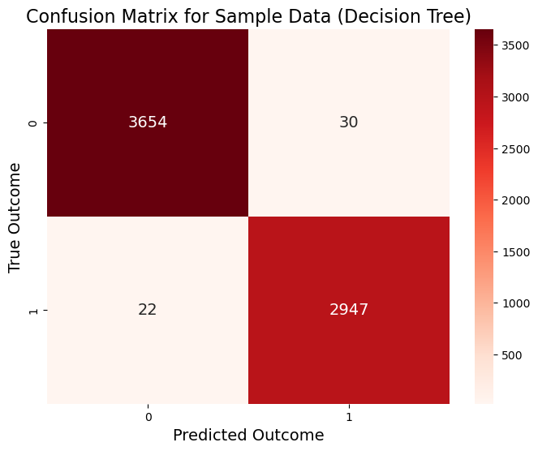

```python
# Read the sample results from the CSV file
sample_results_dt = pd.read_csv('DT_classifier_sample_results.csv')

# Visualize the first few rows of the DataFrame
print("Decision Tree Sample Results:\n", sample_results_dt.sample(10))

# Visualize the confusion matrix as a heatmap for the sample data (Decision Tree)
confusion_dt = confusion_matrix(sample_results_dt['True Outcome'], sample_results_dt['Predicted Outcome'])
plt.figure(figsize=(8, 6))
sns.heatmap(confusion_dt, annot=True, fmt='d', cmap='Reds', annot_kws={'size': 14})
plt.title('Confusion Matrix for Sample Data (Decision Tree)', fontsize=16)
plt.xlabel('Predicted Outcome', fontsize=14)
plt.ylabel('True Outcome', fontsize=14)
plt.show()

# Discuss the strengths and limitations of the implemented Decision Tree model on the sample data
# Emphasize interpretability and implications of the model
```

#### The Decision Tree Classifier demonstrated an outstanding accuracy of 99.22%, indicating a high level of effectiveness in making correct predictions. The confusion matrix reveals that the model correctly predicted the vast majority of instances for both classes, with 3654 correct predictions for class 0 (No) and 2947 correct predictions for class 1 (Yes).

#### The precision, recall, and F1-score for both classes are uniformly high, reflecting the model's balanced and reliable performance in predicting both positive and negative instances. Overall, the Decision Tree Classifier is highly effective for this dataset, with very few misclassifications, making it a robust choice for this classification task.

### Logistic Regression Model

```
Logistic Regression Sample Results:
       True Outcome  Predicted Outcome
615              0                  0
4450             1                  0
1310             1                  1
862              0                  0
2089             1                  1
5235             1                  1
5695             0                  0
1138             0                  0
4165             1                  0
1007             0                  0
```

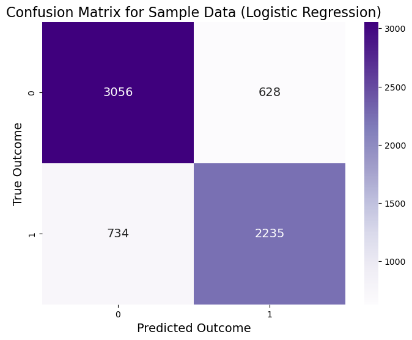

```python
# Read the sample results from the CSV file
sample_results_logreg = pd.read_csv('LogReg_model_sample_results.csv')

# Visualize the first few rows of the DataFrame
print("Logistic Regression Sample Results:\n", sample_results_logreg.sample(10))

# Visualize the confusion matrix as a heatmap for the sample data (Logistic Regression)
confusion_logreg = confusion_matrix(sample_results_logreg['True Outcome'], sample_results_logreg['Predicted Outcome'])
plt.figure(figsize=(8, 6))
sns.heatmap(confusion_logreg, annot=True, fmt='d', cmap='Purples', annot_kws={'size': 14})
plt.title('Confusion Matrix for Sample Data (Logistic Regression)', fontsize=16)
plt.xlabel('Predicted Outcome', fontsize=14)
plt.ylabel('True Outcome', fontsize=14)
plt.show()

# Discuss the strengths and limitations of the implemented Logistic Regression model on the sample data
# Emphasize interpretability and implications of the model
```

#### The Logistic Regression model demonstrated a moderate accuracy of 79.53%, indicating a fair level of effectiveness in making correct predictions. The confusion matrix reveals that the model correctly predicted 3056 instances of class 0 (No) and 2235 instances of class 1 (Yes). However, there were also notable misclassifications, with 628 false positives and 734 false negatives.

#### The precision, recall, and F1-score metrics show that the model performs slightly better for class 0 (No) than for class 1 (Yes), with class 0 having a higher recall (0.83) compared to class 1 (0.75). The weighted average metrics indicate a balanced performance across both classes but highlight areas for potential improvement, especially in reducing false positives and false negatives.

### Artificial Neural Network

```
ANN Sample Results:
       True Outcome  Predicted Outcome
6072             1                  1
3193             1                  1
5162             1                  1
1956             1                  1
5906             1                  1
3654             0                  0
5183             1                  1
2310             1                  1
4464             0                  0
3747             0                  0
```

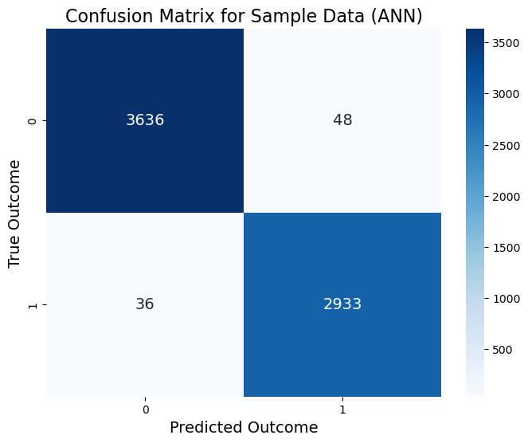

```python
# Read the sample results from the CSV file
sample_results_ann = pd.read_csv('ANN_model_sample_results.csv')

# Visualize the first few rows of the DataFrame
print("ANN Sample Results:\n", sample_results_ann.sample(10))

# Visualize the confusion matrix as a heatmap for the sample data (ANN)
confusion_ann = confusion_matrix(sample_results_ann['True Outcome'], sample_results_ann['Predicted Outcome'])
plt.figure(figsize=(8, 6))
sns.heatmap(confusion_ann, annot=True, fmt='d', cmap='Blues', annot_kws={'size': 14})
plt.title('Confusion Matrix for Sample Data (ANN)', fontsize=16)
plt.xlabel('Predicted Outcome', fontsize=14)
plt.ylabel('True Outcome', fontsize=14)
plt.show()

# Discuss the strengths and limitations of the implemented ANN model on the sample data
# Emphasize the model's complexity and implications
```

### Comparison

```python
# Print the accuracy of the model
print("Accuracy (Random forest classifier):", accuracy_rf)
print("Accuracy (KNeighbor Classifier):", accuracy_knn)
print("Accuracy (Decision Tree):", accuracy_dt)
print("Accuracy (Logistic Regression):", accuracy_logreg)
print("Accuracy (Artificial Neural Network):", accuracy_ann)
```

```
Accuracy (Random forest classifier): 0.9944385991282129
Accuracy (KNeighbor Classifier): 0.9684352923493161
Accuracy (Decision Tree): 0.992183977153164
Accuracy (Logistic Regression): 0.7952803246655644
Accuracy (Artificial Neural Network): 0.9873741169397264
```

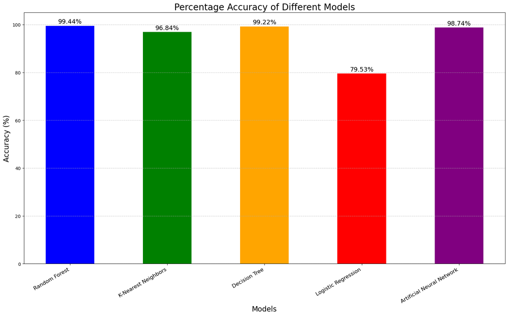

```python
# # Calculate percentage accuracies
# percentage_accuracies = [accuracy * 100 for accuracy in accuracies]

# # Create a bar chart with percentage accuracies
# plt.figure(figsize=(10, 6))
# bars = plt.bar(models, percentage_accuracies, color=['blue', 'green', 'orange', 'red'])

# # Add text labels with the exact percentage values on top of the bars
# for bar, percentage in zip(bars, percentage_accuracies):
#     plt.text(bar.get_x() + bar.get_width() / 2 - 0.1, bar.get_height() + 1,
#              f'{percentage:.2f}%', fontsize=10, color='black')

# plt.title('Percentage Accuracy of Different Models')
# plt.xlabel('Models')
# plt.ylabel('Accuracy (%)')
# plt.ylim(0, 100)  # Set y-axis limit between 0 and 100 for percentage values
# plt.show()

# List of models and their accuracies
models = ['Random Forest', 'K-Nearest Neighbors', 'Decision Tree', 'Logistic Regression', 'Artificial Neural Network']
accuracies = [accuracy_rf, accuracy_knn, accuracy_dt, accuracy_logreg, accuracy_ann]

# Calculate percentage accuracies
percentage_accuracies = [accuracy * 100 for accuracy in accuracies]

# Create a bar chart with percentage accuracies
plt.figure(figsize=(16, 10))
bars = plt.bar(models, percentage_accuracies, color=['blue', 'green', 'orange', 'red', 'purple'], width=0.5)

# Rotate x-axis labels for better readability
plt.xticks(rotation=30, ha='right', fontsize=12)

# Add text labels with the exact percentage values on top of the bars
for bar, percentage in zip(bars, percentage_accuracies):
    plt.text(bar.get_x() + bar.get_width() / 2, bar.get_height() + 1,
             f'{percentage:.2f}%', ha='center', fontsize=14, color='black')

plt.title('Percentage Accuracy of Different Models', fontsize=20)
plt.xlabel('Models', fontsize=16)
plt.ylabel('Accuracy (%)', fontsize=16)
plt.ylim(0, 105)  # Set y-axis limit slightly above 100 for better spacing
plt.grid(axis='y', linestyle='--', alpha=0.7)

plt.tight_layout()  # Adjust layout to fit everything nicely
plt.show()
```